# **Healthcare Provider Fraud Detection**

### **Predictive Analytics for Insurance Claims**

## **Part 1: Problem Statement**

Healthcare fraud is a critical issue that leads to significant financial losses for insurance companies and undermines the healthcare system's integrity. The aim of this project is to develop a predictive model to:

1. **Identify Potentially Fraudulent Providers:**  
   Classify healthcare providers into two categories:
   - **1 = Fraudulent Detected**
   - **0 = Not a Fraud**
2. **Discover Key Fraud Indicators:**  
   Identify important variables and patterns that are strongly associated with fraudulent provider behavior.

This project will empower insurance companies to proactively detect and prevent fraudulent claims, minimizing unnecessary healthcare costs and improving system efficiency.

## **Expected Outcome**

- A machine learning model that classifies healthcare providers into **fraudulent (1)** and **non-fraudulent (0)** categories & Classifying with it's Probability.
- Insights into significant variables and patterns contributing to fraudulent behaviors, helping stakeholders better understand the causes and risk factors of fraud.

## **Objective**

The primary objectives of this project are:

1. **Fraud Detection:**  
   Build a predictive model to accurately identify potentially fraudulent providers based on their claims patterns.
2. **Fraud Analysis:**  
   Uncover critical variables that indicate fraudulent behavior and study patterns in the provider's claims.
3. **Business Impact:**  
   Help insurance companies:
   - Proactively detect and address fraudulent claims.
   - Reduce unnecessary healthcare costs.
   - Improve fraud investigation efficiency.

## **Dataset Overview**

The healthcare claims data consists of three primary datasets:

1. **Inpatient Claims:** Contains details of healthcare providers' inpatient services.
2. **Outpatient Claims:** Includes records of outpatient healthcare services.
3. **Beneficiary Details:** Provides demographic and health-related information of beneficiaries.

These datasets will be merged and analyzed to develop a predictive model for fraud detection.

## 1. Importing Libraries With Each Specific Functionality

```python
import pandas as pd
import numpy as np
import warnings
warnings.filterwarnings("ignore")
```

```python
inpatient = pd.read_csv(r"C:\Users\Nikhil Sukthe\Downloads\Case Study\Case Study\Training Data\Train_Inpatientdata-1542865627584.csv")
outpatient = pd.read_csv(r"C:\Users\Nikhil Sukthe\Downloads\Case Study\Case Study\Training Data\Train_Outpatientdata-1542865627584.csv")
beneficiary = pd.read_csv(r"C:\Users\Nikhil Sukthe\Downloads\Case Study\Case Study\Training Data\Train_Beneficiarydata-1542865627584.csv")
fraud = pd.read_csv(r"C:\Users\Nikhil Sukthe\Downloads\Case Study\Case Study\Training Data\Train-1542865627584.csv")
```

## 2. Visualizing Each Dataset

```python
import matplotlib.pyplot as plt
import seaborn as sns
```

## 2.1 Inpatient & Outpatient Claims

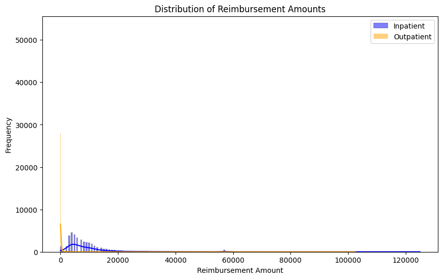

```python
plt.figure(figsize=(10, 6))
sns.histplot(inpatient['InscClaimAmtReimbursed'], kde=True, color='blue', label='Inpatient')
sns.histplot(outpatient['InscClaimAmtReimbursed'], kde=True, color='orange', label='Outpatient')
plt.title('Distribution of Reimbursement Amounts')
plt.xlabel('Reimbursement Amount')
plt.ylabel('Frequency')
plt.legend()
plt.show()
```

## Specific Observation :

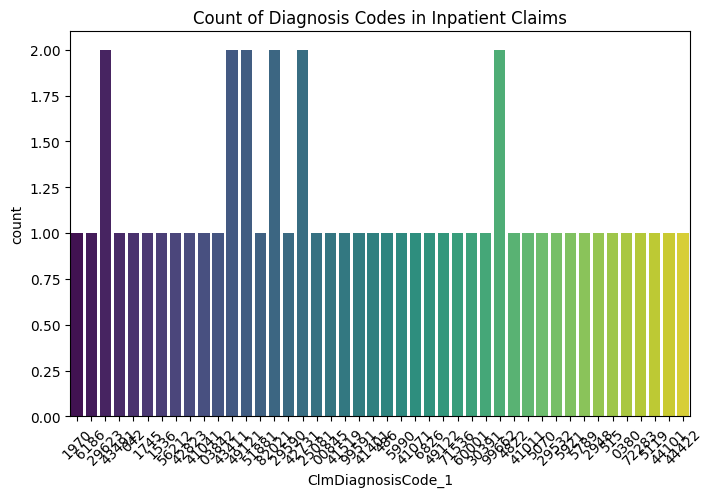

```python
plt.figure(figsize=(8, 5))
sns.countplot(x='ClmDiagnosisCode_1', data=inpatient.head(50), palette='viridis')
plt.title('Count of Diagnosis Codes in Inpatient Claims')
plt.xticks(rotation=45)
plt.show()
```

## 2.2 Beneficiary Dataset

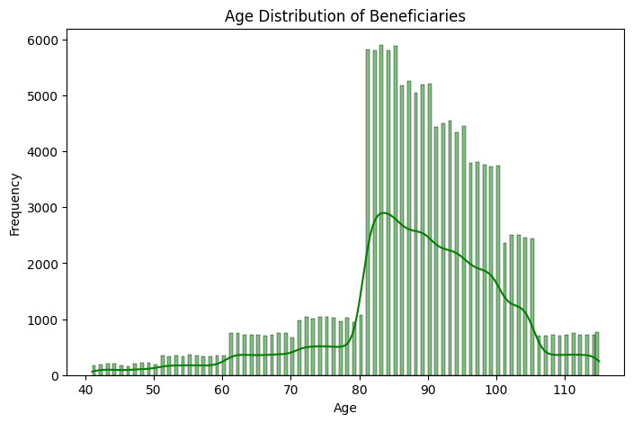

```python
beneficiary['Age'] = 2024 - pd.to_datetime(beneficiary['DOB']).dt.year
plt.figure(figsize=(8, 5))
sns.histplot(beneficiary['Age'], kde=True, color='green')
plt.title('Age Distribution of Beneficiaries')
plt.xlabel('Age')
plt.ylabel('Frequency')
plt.show()
```

## Specific Observations:

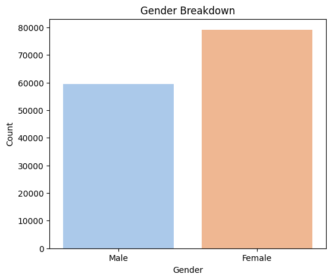

```python
plt.figure(figsize=(6, 5))
gender_counts = beneficiary['Gender'].value_counts()
sns.barplot(x=gender_counts.index, y=gender_counts.values, palette='pastel')
plt.title('Gender Breakdown')
plt.xlabel('Gender')
plt.ylabel('Count')
plt.xticks([0, 1], ['Male', 'Female'])
plt.show()
```

## 2.3 Fraud Dataset

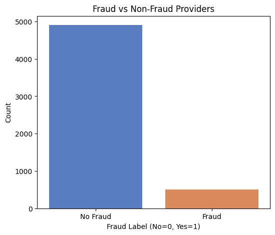

```python
plt.figure(figsize=(6, 5))
fraud_counts = fraud['PotentialFraud'].value_counts()
sns.barplot(x=fraud_counts.index, y=fraud_counts.values, palette='muted')
plt.title('Fraud vs Non-Fraud Providers')
plt.xlabel('Fraud Label (No=0, Yes=1)')
plt.ylabel('Count')
plt.xticks([0, 1], ['No Fraud', 'Fraud'])
plt.show()
```

# 3. Combining Datasets for Merged Analysis

## 3.1 Reimbursement vs Fraud

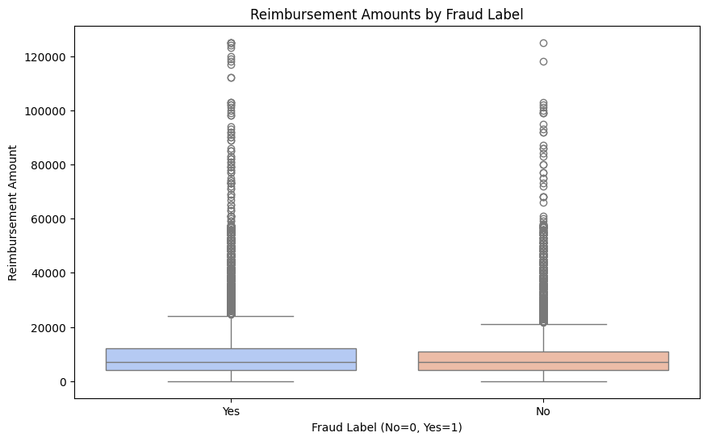

```python
merged = inpatient.merge(fraud, on='Provider', how='inner')

plt.figure(figsize=(10, 6))
sns.boxplot(x='PotentialFraud', y='InscClaimAmtReimbursed', data=merged, palette='coolwarm')
plt.title('Reimbursement Amounts by Fraud Label')
plt.xlabel('Fraud Label (No=0, Yes=1)')
plt.ylabel('Reimbursement Amount')
plt.show()
```

## Observation

- The distribution of reimbursement amounts is significantly skewed towards the right for both "Yes" (fraudulent) and "No" (non-fraudulent) categories.
- This indicates that a large number of claims have relatively low reimbursement amounts, while a smaller number of claims have very high reimbursement amounts.

## 3.2 Chronic Conditions vs Fraud

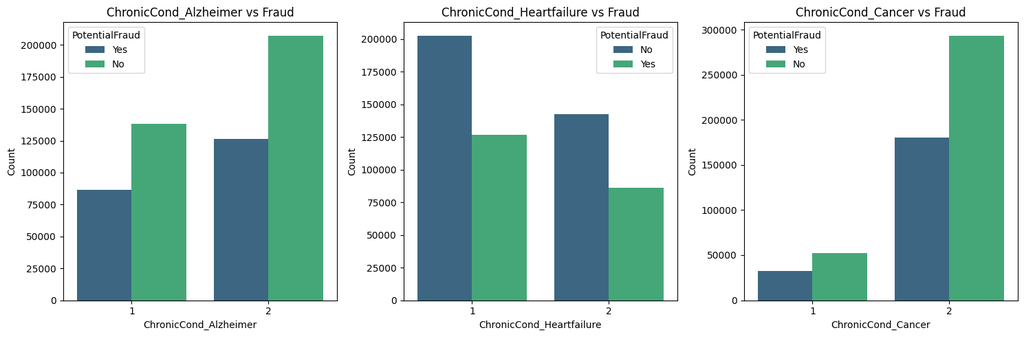

```python
merged_claims = pd.concat([inpatient, outpatient], axis=0).merge(beneficiary, on='BeneID', how='inner')
merged_ben = merged_claims.merge(fraud, on='Provider', how='inner')
chronic_cols = ['ChronicCond_Alzheimer', 'ChronicCond_Heartfailure', 'ChronicCond_Cancer']
plt.figure(figsize=(15, 5))
for i, col in enumerate(chronic_cols):
    plt.subplot(1, 3, i + 1)
    sns.countplot(x=col, hue='PotentialFraud', data=merged_ben, palette='viridis')
    plt.title(f'{col} vs Fraud')
    plt.xlabel(col)
    plt.ylabel('Count')
plt.tight_layout()
plt.show()
```

## 3.3 Correlation Heatmap

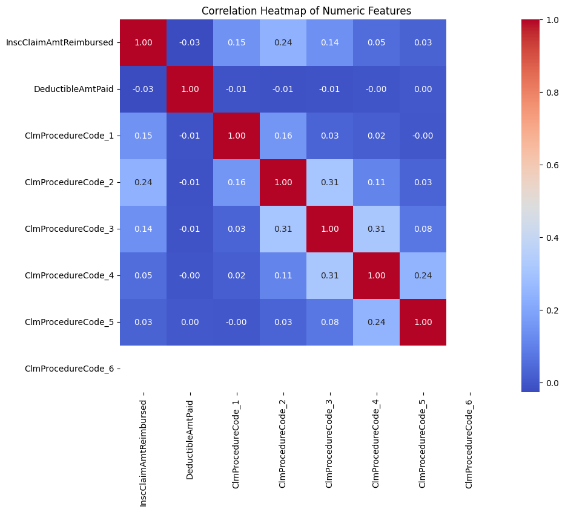

```python
numeric_cols = merged.select_dtypes(include=['float64', 'int64']).columns

merged_numeric = merged[numeric_cols].fillna(0)

plt.figure(figsize=(12, 8))
corr = merged_numeric.corr()
sns.heatmap(corr, annot=True, fmt=".2f", cmap='coolwarm', square=True)
plt.title('Correlation Heatmap of Numeric Features')
plt.show()
```

## 4. Data Merging

```python
claims = pd.concat([inpatient, outpatient], axis=0)
data = claims.merge(beneficiary, on="BeneID", how="inner")
final_data = data.merge(fraud, on="Provider", how="inner")
```

## 5. Data Cleaning

```python
final_data.fillna(0, inplace=True)
final_data['PotentialFraud'] = final_data['PotentialFraud'].map({'Yes': 1, 'No': 0})
```

## 6. Feature Extraction and Engineering

```python
print(final_data.dtypes)
```

```
BeneID                              object
ClaimID                             object
ClaimStartDt                        object
ClaimEndDt                          object
Provider                            object
InscClaimAmtReimbursed               int64
AttendingPhysician                  object
OperatingPhysician                  object
OtherPhysician                      object
AdmissionDt                         object
ClmAdmitDiagnosisCode               object
DeductibleAmtPaid                  float64
DischargeDt                         object
DiagnosisGroupCode                  object
ClmDiagnosisCode_1                  object
ClmDiagnosisCode_2                  object
ClmDiagnosisCode_3                  object
ClmDiagnosisCode_4                  object
ClmDiagnosisCode_5                  object
ClmDiagnosisCode_6                  object
ClmDiagnosisCode_7                  object
ClmDiagnosisCode_8                  object
ClmDiagnosisCode_9                  object
ClmDiagnosisCode_10                 object
ClmProcedureCode_1                 float64
ClmProcedureCode_2                 float64
ClmProcedureCode_3                 float64
ClmProcedureCode_4                 float64
ClmProcedureCode_5                 float64
ClmProcedureCode_6                 float64
DOB                                 object
DOD                                 object
Gender                               int64
Race                                 int64
RenalDiseaseIndicator               object
State                                int64
County                               int64
NoOfMonths_PartACov                  int64
NoOfMonths_PartBCov                  int64
ChronicCond_Alzheimer                int64
ChronicCond_Heartfailure             int64
ChronicCond_KidneyDisease            int64
ChronicCond_Cancer                   int64
ChronicCond_ObstrPulmonary           int64
ChronicCond_Depression               int64
ChronicCond_Diabetes                 int64
ChronicCond_IschemicHeart            int64
ChronicCond_Osteoporasis             int64
ChronicCond_rheumatoidarthritis      int64
ChronicCond_stroke                   int64
IPAnnualReimbursementAmt             int64
IPAnnualDeductibleAmt                int64
OPAnnualReimbursementAmt             int64
OPAnnualDeductibleAmt                int64
Age                                  int32
PotentialFraud                       int64
dtype: object
```

```python
print(final_data.dtypes)

final_data['Gender'] = pd.to_numeric(final_data['Gender'], errors='coerce')
final_data['ChronicCond_Alzheimer'] = pd.to_numeric(final_data['ChronicCond_Alzheimer'], errors='coerce')
final_data['RenalDiseaseIndicator'] = pd.to_numeric(final_data['RenalDiseaseIndicator'], errors='coerce')

agg_features = final_data.groupby('Provider').agg({
    'ClaimID': 'count',  # Total claims
    'InscClaimAmtReimbursed': 'sum',
    'ClmDiagnosisCode_1': 'nunique',
    'ClmProcedureCode_1': 'nunique',
    'Gender': 'mean',
    'ChronicCond_Alzheimer': 'mean',
    'RenalDiseaseIndicator': 'mean'
}).reset_index()

agg_features.rename(columns={
    'ClaimID': 'Total_Claims',
    'InscClaimAmtReimbursed': 'Total_Reimbursed',
    'ClmDiagnosisCode_1': 'Unique_Diagnoses',
    'ClmProcedureCode_1': 'Unique_Procedures'
}, inplace=True)

dataset = agg_features.merge(fraud, on='Provider')
```

```
BeneID                              object
ClaimID                             object
ClaimStartDt                        object
ClaimEndDt                          object
Provider                            object
InscClaimAmtReimbursed               int64
AttendingPhysician                  object
OperatingPhysician                  object
OtherPhysician                      object
AdmissionDt                         object
ClmAdmitDiagnosisCode               object
DeductibleAmtPaid                  float64
DischargeDt                         object
DiagnosisGroupCode                  object
ClmDiagnosisCode_1                  object
ClmDiagnosisCode_2                  object
ClmDiagnosisCode_3                  object
ClmDiagnosisCode_4                  object
ClmDiagnosisCode_5                  object
ClmDiagnosisCode_6                  object
ClmDiagnosisCode_7                  object
ClmDiagnosisCode_8                  object
ClmDiagnosisCode_9                  object
ClmDiagnosisCode_10                 object
ClmProcedureCode_1                 float64
ClmProcedureCode_2                 float64
ClmProcedureCode_3                 float64
ClmProcedureCode_4                 float64
ClmProcedureCode_5                 float64
ClmProcedureCode_6                 float64
DOB                                 object
DOD                                 object
Gender                               int64
Race                                 int64
RenalDiseaseIndicator               object
State                                int64
County                               int64
NoOfMonths_PartACov                  int64
NoOfMonths_PartBCov                  int64
ChronicCond_Alzheimer                int64
ChronicCond_Heartfailure             int64
ChronicCond_KidneyDisease            int64
ChronicCond_Cancer                   int64
ChronicCond_ObstrPulmonary           int64
ChronicCond_Depression               int64
ChronicCond_Diabetes                 int64
ChronicCond_IschemicHeart            int64
ChronicCond_Osteoporasis             int64
ChronicCond_rheumatoidarthritis      int64
ChronicCond_stroke                   int64
IPAnnualReimbursementAmt             int64
IPAnnualDeductibleAmt                int64
OPAnnualReimbursementAmt             int64
OPAnnualDeductibleAmt                int64
Age                                  int32
PotentialFraud                       int64
dtype: object
```

```python
print(final_data.dtypes)
```

```
BeneID                              object
ClaimID                             object
ClaimStartDt                        object
ClaimEndDt                          object
Provider                            object
InscClaimAmtReimbursed               int64
AttendingPhysician                  object
OperatingPhysician                  object
OtherPhysician                      object
AdmissionDt                         object
ClmAdmitDiagnosisCode               object
DeductibleAmtPaid                  float64
DischargeDt                         object
DiagnosisGroupCode                  object
ClmDiagnosisCode_1                  object
ClmDiagnosisCode_2                  object
ClmDiagnosisCode_3                  object
ClmDiagnosisCode_4                  object
ClmDiagnosisCode_5                  object
ClmDiagnosisCode_6                  object
ClmDiagnosisCode_7                  object
ClmDiagnosisCode_8                  object
ClmDiagnosisCode_9                  object
ClmDiagnosisCode_10                 object
ClmProcedureCode_1                 float64
ClmProcedureCode_2                 float64
ClmProcedureCode_3                 float64
ClmProcedureCode_4                 float64
ClmProcedureCode_5                 float64
ClmProcedureCode_6                 float64
DOB                                 object
DOD                                 object
Gender                               int64
Race                                 int64
RenalDiseaseIndicator              float64
State                                int64
County                               int64
NoOfMonths_PartACov                  int64
NoOfMonths_PartBCov                  int64
ChronicCond_Alzheimer                int64
ChronicCond_Heartfailure             int64
ChronicCond_KidneyDisease            int64
ChronicCond_Cancer                   int64
ChronicCond_ObstrPulmonary           int64
ChronicCond_Depression               int64
ChronicCond_Diabetes                 int64
ChronicCond_IschemicHeart            int64
ChronicCond_Osteoporasis             int64
ChronicCond_rheumatoidarthritis      int64
ChronicCond_stroke                   int64
IPAnnualReimbursementAmt             int64
IPAnnualDeductibleAmt                int64
OPAnnualReimbursementAmt             int64
OPAnnualDeductibleAmt                int64
Age                                  int32
PotentialFraud                       int64
dtype: object
```

# 7. Model Selection

# Categorizing Why LGBM Model is Perfect :

**LightGBM (LGBM)**

1. **High Efficiency and Scalability**: LightGBM is optimized for large datasets, using a histogram-based approach to reduce memory usage and computation time, making it fast and scalable for complex problems like fraud detection.
2. **Handling Imbalanced Data**: It excels in dealing with class imbalance, crucial in fraud detection, by using parameters like **`scale_pos_weight`** to adjust the model's learning and enhance performance on minority classes (fraudulent claims).

```python
from lightgbm import LGBMClassifier
from sklearn.model_selection import train_test_split, StratifiedKFold
from sklearn.metrics import classification_report, roc_auc_score, confusion_matrix
from imblearn.over_sampling import SMOTE
```

```python
X = dataset.drop(columns=['Provider', 'PotentialFraud'])
y = dataset['PotentialFraud']

X_train, X_test, y_train, y_test = train_test_split(X, y, test_size=0.2, random_state=42, stratify=y)
```

## 8. Handle Class Imbalance

```python
from sklearn.impute import SimpleImputer
from imblearn.over_sampling import SMOTE
```

## 8.1: Handle Missing Values

```python
imputer = SimpleImputer(strategy='mean')
X_train_imputed = imputer.fit_transform(X_train)
```

## 8.2: Handle Class Imbalance with SMOTE

```python
smote = SMOTE(random_state=42)
X_train_resampled, y_train_resampled = smote.fit_resample(X_train_imputed, y_train)
print("Resampling completed successfully.")
```

```
Resampling completed successfully.
```

## 8.3: Calculate Class Weight for LightGBM

```python
class_weight = y_train.value_counts()[0] / y_train.value_counts()[1]
```

## 8.4 Verification -->

```python
print("Number of NaN values in X_train_resampled:", np.isnan(X_train_resampled).sum())
```

```
Number of NaN values in X_train_resampled: 0
```

## 8.5 Hyperparameter Tuning

```python
from sklearn.model_selection import GridSearchCV
```

```python
param_grid = {
    'n_estimators': [100, 300, 500, 1000],
    'learning_rate': [0.01, 0.03, 0.05, 0.1],
    'max_depth': [5, 7, 10],
    'min_child_samples': [20, 50, 100],
    'subsample': [0.7, 0.8, 1.0],
    'colsample_bytree': [0.7, 0.8, 1.0],
    'scale_pos_weight': [class_weight, 2 * class_weight]
}

lgbm = LGBMClassifier(random_state=42)

grid_search = GridSearchCV(
    estimator=lgbm,
    param_grid=param_grid,
    scoring='roc_auc',
    cv=5,  # 5-fold cross-validation
    verbose=1,
    n_jobs=-1
)

grid_search.fit(X_train_resampled, y_train_resampled)
```

[output not shown]

[output cut: 120 more lines]

[output not shown]

```
GridSearchCV(cv=5, estimator=LGBMClassifier(random_state=42), n_jobs=-1,
             param_grid={'colsample_bytree': [0.7, 0.8, 1.0],
                         'learning_rate': [0.01, 0.03, 0.05, 0.1],
                         'max_depth': [5, 7, 10],
                         'min_child_samples': [20, 50, 100],
                         'n_estimators': [100, 300, 500, 1000],
                         'scale_pos_weight': [9.686419753086419,
                                              19.372839506172838],
                         'subsample': [0.7, 0.8, 1.0]},
             scoring='roc_auc', verbose=1)
```

```python
print("Best Parameters:", grid_search.best_params_)
```

```
Best Parameters: {'colsample_bytree': 0.8, 'learning_rate': 0.1, 'max_depth': 7, 'min_child_samples': 20, 'n_estimators': 1000, 'scale_pos_weight': 19.372839506172838, 'subsample': 0.7}
```

## 9 .Training LightGBM Model

```python
from lightgbm import LGBMClassifier, early_stopping
```

```python
lgbm = LGBMClassifier(
    random_state=42,
    **best_params
)


lgbm.fit(
    X_train_resampled,
    y_train_resampled,
    eval_set=[(X_test, y_test)],
    eval_metric='auc',
    callbacks=[early_stopping(stopping_rounds=50, verbose=True)]
)
```

```
[LightGBM] [Info] Number of positive: 3923, number of negative: 3923
[LightGBM] [Info] Auto-choosing col-wise multi-threading, the overhead of testing was 0.000758 seconds.
You can set `force_col_wise=true` to remove the overhead.
[LightGBM] [Info] Total Bins 1530
[LightGBM] [Info] Number of data points in the train set: 7846, number of used features: 6
[LightGBM] [Info] [binary:BoostFromScore]: pavg=0.500000 -> initscore=0.000000
Training until validation scores don't improve for 50 rounds
[LightGBM] [Warning] No further splits with positive gain, best gain: -inf
[LightGBM] [Warning] No further splits with positive gain, best gain: -inf
Early stopping, best iteration is:
[31]	valid_0's auc: 0.930118	valid_0's binary_logloss: 0.67434
```

```
LGBMClassifier(colsample_bytree=0.8, max_depth=7, n_estimators=1000,
               random_state=42, scale_pos_weight=19.372839506172838,
               subsample=0.7)
```

### 10. MODEL EVALUATION

```python
y_pred = lgbm.predict(X_test)
y_prob = lgbm.predict_proba(X_test)[:, 1]
print("Classification Report:")
print(classification_report(y_test, y_pred))

print("ROC-AUC Score:", roc_auc_score(y_test, y_prob))
```

[output not shown]

[figure not shown]

```python
cm = confusion_matrix(y_test, y_pred)
sns.heatmap(cm, annot=True, fmt="d", cmap="Blues")
plt.title("Confusion Matrix")
plt.show()
```

## 11. Testing Model Functionality

```python
test_providers = pd.read_csv(r"C:\Users\Nikhil Sukthe\Downloads\Case Study\Case Study\Unseen Data\Unseen-1542969243754.csv")

test_inpatient = pd.read_csv(r"C:\Users\Nikhil Sukthe\Downloads\Case Study\Case Study\Unseen Data\Unseen_Inpatientdata-1542969243754.csv")
test_outpatient = pd.read_csv(r"C:\Users\Nikhil Sukthe\Downloads\Case Study\Case Study\Unseen Data\Unseen_Outpatientdata-1542969243754.csv")
test_beneficiary = pd.read_csv(r"C:\Users\Nikhil Sukthe\Downloads\Case Study\Case Study\Unseen Data\Unseen_Beneficiarydata-1542969243754.csv")
```

```python
test_claims = pd.concat([test_inpatient, test_outpatient], axis=0)

test_data = test_claims.merge(test_beneficiary, on="BeneID", how="inner")
numeric_columns = ['Gender', 'ChronicCond_Alzheimer', 'RenalDiseaseIndicator']
for col in numeric_columns:
    test_data[col] = pd.to_numeric(test_data[col], errors='coerce')


test_data.fillna(0, inplace=True)


test_features = test_data.groupby('Provider').agg({
    'ClaimID': 'count',
    'InscClaimAmtReimbursed': 'sum',
    'ClmDiagnosisCode_1': 'nunique',
    'ClmProcedureCode_1': 'nunique',
    'Gender': 'mean',
    'ChronicCond_Alzheimer': 'mean',
    'RenalDiseaseIndicator': 'mean'
}).reset_index()


test_features.rename(columns={
    'ClaimID': 'Total_Claims',
    'InscClaimAmtReimbursed': 'Total_Reimbursed',
    'ClmDiagnosisCode_1': 'Unique_Diagnoses',
    'ClmProcedureCode_1': 'Unique_Procedures'
}, inplace=True)

final_test_features = test_features.merge(test_providers, on='Provider', how='inner')
```

```python
test_X = final_test_features.drop(columns=['Provider'])

final_test_features['PotentialFraud_Prob'] = lgbm.predict_proba(test_X)[:, 1]
final_test_features['PotentialFraud_Class'] = lgbm.predict(test_X)

submission_file = final_test_features[['PotentialFraud_Prob', 'PotentialFraud_Class']]
submission_file.to_csv(r"C:\Users\Nikhil Sukthe\Downloads\NikhilSukthe_Submission.csv", index=False)

print("Test predictions saved successfully!")
```

```
Test predictions saved successfully!
```

## 12. Prediction Analysis

### CASE-STUDY 1.1 : DISTRIBUTION OF PREDICTED FRAUD PROBABILITIES

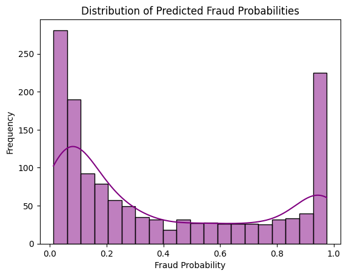

```python
predictions = pd.read_csv(r"C:\Users\Nikhil Sukthe\Downloads\NikhilSukthe_Submission.csv")
sns.histplot(predictions['PotentialFraud_Prob'], kde=True, bins=20, color='purple')
plt.title("Distribution of Predicted Fraud Probabilities")
plt.xlabel("Fraud Probability")
plt.ylabel("Frequency")
plt.show()
```

### CASE-STUDY 1.2 : PREDICTED FRUAD VS NON - FRUAD

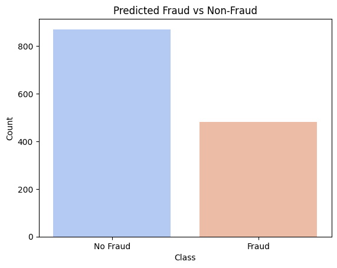

```python
sns.countplot(x='PotentialFraud_Class', data=predictions, palette='coolwarm')
plt.title("Predicted Fraud vs Non-Fraud")
plt.xlabel("Class")
plt.ylabel("Count")
plt.xticks([0, 1], ['No Fraud', 'Fraud'])
plt.show()
```

### CASE STUDY 1.3 - PROVIDERS WITH HIGH FRAUD PROBABILITY

```python
high_risk_providers = predictions[predictions['PotentialFraud_Prob'] > 0.8]

print("High-Risk Providers:")
print(high_risk_providers)

num_high_risk_providers = high_risk_providers.shape[0]
print(f"Number of High-Risk Providers: {num_high_risk_providers}")
```

```
High-Risk Providers:
      PotentialFraud_Prob PotentialFraud_Class
7                0.842663                  Yes
11               0.971474                  Yes
13               0.880401                  Yes
14               0.972137                  Yes
15               0.975095                  Yes
...                   ...                  ...
1305             0.970615                  Yes
1309             0.952202                  Yes
1313             0.974820                  Yes
1319             0.923702                  Yes
1328             0.917844                  Yes

[319 rows x 2 columns]
Number of High-Risk Providers: 319
```

# **Approach Overview**

## 1. **Data Exploration and Preprocessing**

First, I started by merging the **inpatient**, **outpatient**, and **beneficiary** datasets. The goal was to create a unified dataset that connects claims data to the beneficiaries and their providers. I handled missing values carefully, either by filling them with zeros or using imputation techniques where needed.

During this step, I also ensured all columns were properly formatted—for example, converting categorical variables like `Gender` or chronic conditions into numeric values so they could be used effectively in the model.

Next, I performed **Exploratory Data Analysis (EDA)** to understand the structure of the data. I visualized the distribution of reimbursement amounts, analyzed the breakdown of fraud and non-fraud cases, and checked for class imbalance in the dataset. This helped me identify patterns in claims data, such as common diagnoses and procedures that might be linked to fraudulent behavior.

## 2. **Feature Engineering**

Once I understood the data, the next step was to engineer useful features.

## 3. **Model Development**

For modeling, I selected **LightGBM**, which is a gradient boosting algorithm well-suited for large datasets and imbalanced problems like fraud detection.

- I split the data into training and testing sets using **stratified sampling** to ensure that the distribution of fraud and non-fraud cases was preserved in both sets.
- Since fraud cases are much less common than non-fraud cases, I addressed this **class imbalance** by applying **SMOTE (Synthetic Minority Over-sampling Technique)** to generate synthetic fraud samples. Additionally, I used LightGBM’s built-in parameter `scale_pos_weight` to further adjust for the imbalance.

To ensure I got the best performance, I optimized the model's hyperparameters, such as learning rate, number of estimators, and maximum tree depth, using **GridSearchCV**.

## 4. **Insights and Evaluation**

After training the model, I evaluated its performance using key metrics like **Precision, Recall, F1-Score**, and **ROC-AUC**. These metrics helped me assess how effectively the model was identifying fraud cases while minimizing false positives and false negatives.

# **Business Recommendations and Improvements**

## **1. Leverage Predictive Insights for Fraud Prevention**

- Let me start with **actionable fraud detection**. Our model provides the ability to **rank providers based on their fraud risk**. What this means is that we can now focus manual audits on high-risk providers, making the process much more efficient. For low-risk providers, we can automate claim approvals, significantly reducing processing time and operational costs.
- Another aspect here is **enhanced provider profiling**. By analyzing flagged providers' patterns, such as specific diagnosis or procedure codes linked to fraud, we can refine internal fraud-detection policies. This insight can also help us set up early-warning systems to flag providers exhibiting similar behaviors.

## **2. Data Utilization Strategies**

- Data is critical. One improvement is to **enrich current datasets** by integrating additional sources. For example, we could add claim narratives, billing notes, or even provider reviews. Using tools like Natural Language Processing (NLP), we could extract meaningful patterns from text, revealing hidden fraudulent behaviors.
- Another important strategy is **data refresh cycles**. Fraudulent behavior evolves, so periodically updating our training dataset with new claims data and outcomes from flagged cases ensures the model stays effective and relevant over time.

## **3. Scalable Deployment and Operationalization**

- Real-world deployment is essential. We should focus on **real-time integration** of the model into the claims processing system using APIs. This would allow immediate scoring of claims, with high-risk cases flagged for manual review before payouts are made. This ensures we catch fraud before it affects finances.
- Once deployed, we need **model monitoring and feedback mechanisms**. For example, we’ll track metrics like accuracy, precision, and recall in production. Verified outcomes, like identifying false positives or negatives, can be fed back into the system to improve the model continuously.

## **4. Advanced Model Improvements**

- Let’s talk about making the model more transparent. Using **explainable AI tools** like SHAP or LIME, we can interpret the model's decisions. For example, we could highlight features like claim amounts or specific diagnosis codes that contribute most to a provider being flagged as fraudulent. This helps stakeholders understand and trust the system.
- A related idea is to implement a **custom risk scoring system** instead of just classifying providers as fraudulent or not. By assigning a risk score, we can prioritize investigations based on severity, ensuring efficient resource allocation.

## **5. Business Process Optimization**

- Fraud detection directly improves operational efficiency. **Automating fraud detection** reduces the need for manual review, allowing teams to focus on investigating the most critical cases. This improves throughput and saves costs.
- Additionally, fraud insights can drive **premium adjustments**. For example, providers flagged as high-risk might see their premiums increase, while compliant providers benefit from lower rates. This approach not only reduces fraud but also incentivizes good practices.

## **6. Long-Term Organizational Benefits**

- These improvements translate to tangible benefits. **Cost reduction** is a major outcome, as fewer fraudulent claims mean fewer payouts and more resources for genuine claims. This could even lead to reduced premium rates for customers.
- At the same time, **improved customer trust** comes from transparent and efficient fraud detection. Customers and regulators will see this as a sign of fairness and reliability.
- Finally, this system is **scalable**. The framework developed here can be extended to other insurance domains, such as auto or life insurance, broadening the organization’s fraud detection capabilities.

## **7. Suggested Enhancements for Future Scope**

- Looking ahead, we could introduce **unsupervised learning models** for anomaly detection. This would allow us to identify fraud patterns not captured in our current dataset, keeping us a step ahead of fraudsters.
- Additionally, **geographic and temporal analysis** could reveal trends, like certain regions or times of the year having higher fraud rates. These insights can further refine our fraud detection strategies.

## Final Report

For the detailed report and visual insights, refer to the Canva link below:

[Click here to view the final report](https://www.canva.com/design/DAGXyAPjXM8/xd-cSmoawcACnS3YNxvYyw/view?utm_content=DAGXyAPjXM8&utm_campaign=designshare&utm_medium=link&utm_source=editor)

I would like to express my sincere gratitude for the opportunity to contribute to this project. It has been a valuable experience, and I am eager to receive any further insights or feedback for continued improvement and collaboration.